# Statistical inference with the GSS data

## Setup

### Load packages

```r
library(ggplot2)
library(dplyr)
library(statsr)
library(plyr)
library(visualize)
```

### Load data

Make sure your data and R Markdown files are in the same directory. When loaded your data file will be called `gss`. Delete this note when before you submit your work.

```r
load("gss.Rdata")
```

## Part 1: Data

About GSS:

Since 1972, the General Social Survey (GSS) has been monitoring societal change and studying the growing complexity of American society. The GSS aims to gather data on contemporary American society in order to monitor and explain trends and constants in attitudes, behaviors, and attributes; to examine the structure and functioning of society in general as well as the role played by relevant subgroups; to compare the United States to other societies in order to place American society in comparative perspective and develop cross-national models of human society; and to make high-quality data easily accessible to scholars, students, policy makers, and others, with minimal cost and waiting.

GSS questions cover a diverse range of issues including national spending priorities, marijuana use, crime and punishment, race relations, quality of life, confidence in institutions, and sexual behavior.(Source: Duke University Data and Visualization Services)

About the Data:

GSS data consists of 57061 observations of 114 variables. Unlike the full General Social Survey Cumulative File, the extract has been cleaned by removing missing values from the responses to facilitate analysis using R.

The scope of inference:

The GSS sample is drawn using an area probability design that randomly selects respondents in households across the United States to take part in the survey. Respondents that become part of the GSS sample are from a mix of urban, suburban, and rural geographic areas. Participation in the study is strictly voluntary. However, because only about a few thousand respondents are interviewed in the main study, every respondent selected is very important to the results.

The survey is conducted face-to-face with an in-person interview by NORC at the University of Chicago.

Since this is an observational study,we can’t make causal inferences from this. * * *

## Part 2: Research question

The research question here is that- “Whether there is any difference in proportion of the workers who are”Very Satisfied" with their job, on the basis of Caste for the year 2012?"

This question is of interest because there is often discrimination reported with the workers based on their caste. So, if there is no discrimination , there should not be evident difference in the proportion of workers who are very satisfied with their jobs.

## Part 3: Exploratory data analysis

Filtering 2012 data

```r
subgss<-filter(gss,year==2012)
```

Job satisfaction table (jobsat_tbl) for the year 2012 based on caste

```r
jobsat_tbl<-table(subgss$satjob,subgss$race)
Total<-c(Total=rowSums(jobsat_tbl))
jobsat_tbl<-cbind(jobsat_tbl,Total)
Total<-c(Total=colSums(jobsat_tbl))
jobsat_tbl<-rbind(jobsat_tbl,Total)
jobsat_tbl
```

```
##                   White Black Other Total
## Very Satisfied      574    82    76   732
## Mod. Satisfied      371   104    64   539
## A Little Dissat      91    28    17   136
## Very Dissatisfied    34     8     8    50
## Total              1070   222   165  1457
```

Preparing job satisfaction data frame (jobsatbyrace) for analysis

```r
jobsatbyrace<-data.frame(table(subgss$satjob,subgss$race))
colnames(jobsatbyrace)<-c("Satisfaction","Race","Frequency")
jobsatbyrace$Sumbygrp<-c(rep(1070,4),rep(222,4),rep(165,4))
jobsatbyrace <- ddply(jobsatbyrace, .(Satisfaction), transform, pos = cumsum((Frequency/Sumbygrp)*100) - (0.5 * (Frequency/Sumbygrp)*100))
```

Plotting bar plot demonstrating fraction of workers among various caste categorised by job satisfaction

[figure not shown]

```r
ggplot(data=jobsatbyrace, aes(x=Satisfaction, y=round((Frequency/Sumbygrp)*100,digits = 2), fill=Race))+ geom_bar(stat="identity")+geom_text(data=jobsatbyrace, aes(x = Satisfaction, y = pos,label = paste0(round((Frequency/Sumbygrp)*100,digits = 2),"%")), size=4)+labs(y="Percentage")
```

Here, we can see there is some difference in job satisfaction level across Whites,Blacks and Others. To find out wether this difference provides enough evidence that there is some difference,we conduct hypothesis test.For our research purpose we concentrate only on the workers which are “Very Satisfied”. * * *

## Part 4: Inference

Null Hypothesis: There is no difference in the no. of workers who are “Very Satisfied” with their jobs across different castes.

Alternative Hypothesis: There is some difference in the no. of workers who are “Very Satisfied” with their jobs across different castes.

For this we conduct a chi-square test at 95% confidence to see the difference in the observed and expected values of workers who are “Very Satisfied”

Conditions for the chi-square test:

1. Independence- As mentioned earlier, the sample was randomly taken by GSS. Sample size,n=1457 < 10% of the population. Each case contributes only to one cell in the table.
2. Sample size - Each cell has at least 5 expected cases.

As conditions are satisfied, we can proceed with our test.

Calculating Expected workers : Formula for calculating workers who are Expected to be “Very Satisfied” is: (Total Workers by caste/Total workers)* No.of “Very satisfied” workers by caste

For example, for whites, (1070/1457)*732

Displaying Observed vs Expected in data frame (jobv_sat)

```r
jobv_sat<-data.frame(Observed=c(574,82,76),Expected=c(537,112,83))
rownames(jobv_sat)<-c("White","Black","Other")
jobv_sat
```

```
##       Observed Expected
## White      574      537
## Black       82      112
## Other       76       83
```

Now, we calculate chi-square statistics using formula: (O1-E1)^2/E1 + (O2-E2)^2/E2 +(O3-E3)^2/E3

calculating Chi-square

```r
chisq_value<- ((574-537)^2/537)+((82-112)^2/112)+((76-83)^2/83)
chisq_value
```

```
## [1] 11.17542
```

Now, let’s calculate p-value for this chi-square statistics

```r
pchisq(chisq_value,2,lower.tail = FALSE)
```

```
## [1] 0.003743583
```

We can see p<0.05 , thus we reject Null hypothesis for Alternative one.

To visualize chi-square distribution graph we can use “visualize” package

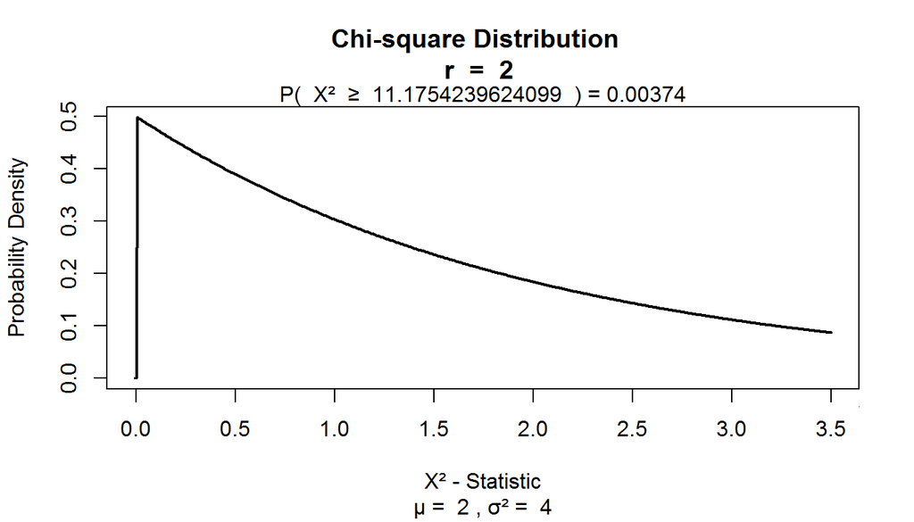

```r
visualize.chisq(stat=chisq_value,df=2,section="upper")
```

Here also, we can see p<0.05 and in the distribution as chi-square statistic is so large(>11) it cannot be observed on graph.